# (Fordgo bike data exploration)

## by (Omnia Imam)

## Investigation Overview

> How long does the average trip take?, and does that depend on if a user is a subscriber or customer? How can some other variables be relevant; (such as gender of that user, or maybe their age..! )

## Dataset Overview

> This document explores a dataset including information about individual rides made in a bike-sharing system covering the greater San FranciscoBay area.

## Univariate Exploration

### 1- Distribution of durations of rides in minutes- (Histogram)

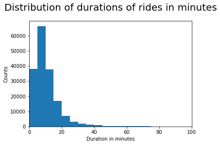

- The majority of rides do not exceed 20 mins; do not even reach them, with **average time duration of 11.49 minutes..**
- our plot is right skewed which indicates that **with the increasement of durations, number of riders tends to decrease..**

### 2- Which days of the week are most likely to have more reservations recorded on- (Barchart)

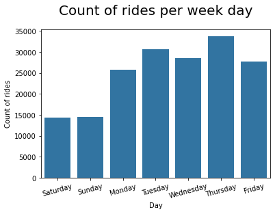

The **majority of rides** are reserved on (**Thursday** and **Tuesday**, respectively) , then on Wednesday, Friday and Monday, While having **Saturday and Sunday with the least frequencies of reservations..**

### 3- Distribution of members' types- (PieChart)

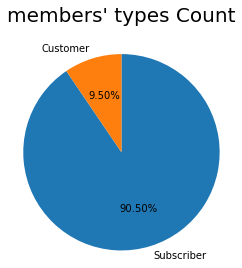

Generally, the **higher proportion** of bike-riders are **subscribers**..

### 4- Distribution of members' genders- (Barchart)

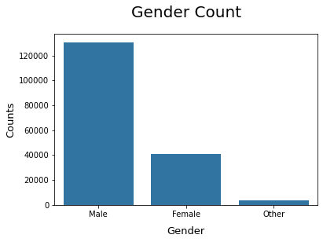

**Male** bike-riders are much **more than females and others**..

### 5- Distribution of members' Ages- (Histogram with gaps)

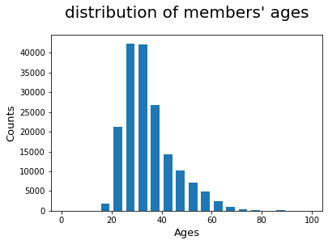

**Most of the distribution** fall within the range of **20-40** years old members, with **mean value of 34 years old** and we can also notice that our graph is considered right skewed; meaning that **number of riders decreases as their ages increase**..

## Bivariate Exploration

### 1- **First of all, let's have a look at the relationship between types of users and time they spend riding bikes**

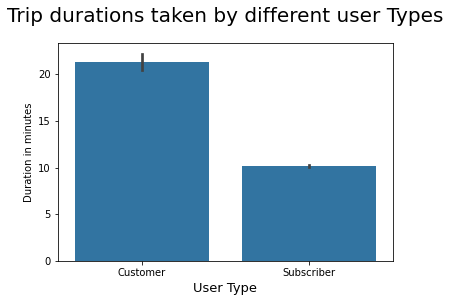

On average, **Customers spend more Time riding bikes than subscribers**

### 2- **Let's now have a look at the relationship between types of users and days of week they mostly reserve rides on**

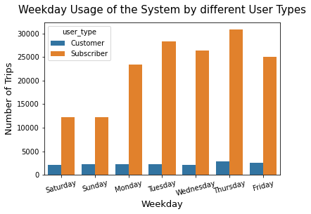

Subscribers are much more than customers, and **"Thursday" is still the most frequent day** of reserving rides for both types, **followed by "Friday" for customers**, and **"Tuesday" for subscribers

### 3- **Now let's see the relationship between week days and trip duration**

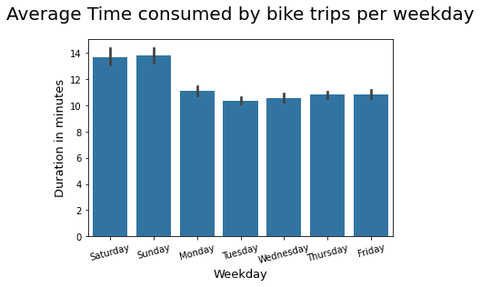

**"Sunday"** is the day with the **highest average of trip durations** in minutes, **followed by "Saturday"**, then **"Monday"**. The rest of week days are so close in average durations

### 4- **Is there a relationship between members' genders and trips durations?**

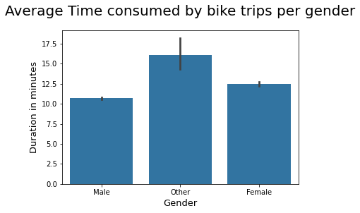

**"Other"** gender seems to spend the **highest average of time duration** in riding bikes, **followed by females**, then males.

### 5- **Is there a relationship between members' ages and trip durations?**

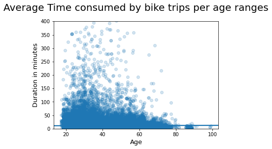

#### Verifying by a Heatmap:

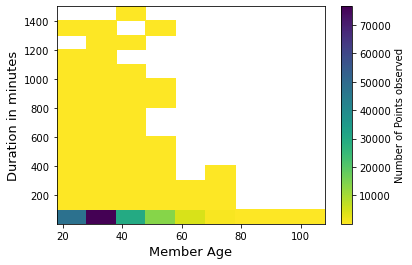

We can observe from both the scatter plot and heat map that **most frequent** bike riders are aged **between 20 and 60**. And that **Higher durations are mostly observed with younger members**.

## Multivariate Exploration

### 1- **Relationship between member age , gender and trip duration**

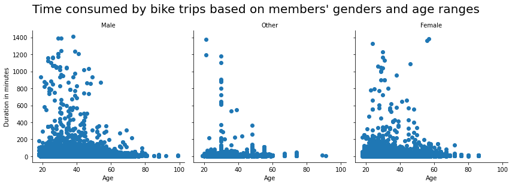

> **Higher durations** are occupied by **ages mostly less than 60** .

> On average,"**Other**" gender is considered the **lowest aged** riding bikes gender , **followed by Females** then Males.

> There's no really obvious effect on duration based on gender, Except that there are **more data points of males of ages less than 50, that were observed to have spent high durations of time**..

### 2- **Relationship between user type, gender and weekday usage.**

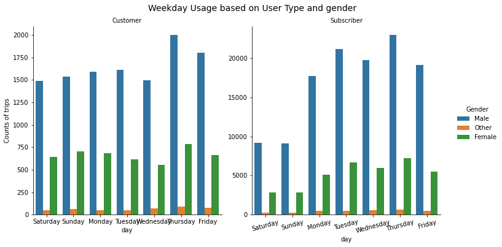

> **Subscribers are much more than customers**, and **males are making more bike trips than females and others;** as a nature result of their high numbers in the program.

> "**Thursday**" is still **the most frequent day of reserving rides for both types**, followed by **"Friday" for customers**, and **"Tuesday" for subscribers**.

### In Conclusion, regarding our features of interest (**user_type, average trip duration**):

> - The majority of rides do not exceed 20 mins; with **average time duration of 11.49 minutes**.
> - With the **increasement** of trip **durations** ,**number of riders** tends to **decrease**.
> - **most users are subscribers** ,They both prefer using the Bikeshare on **Thursdays**, followed by **"Friday" for customers**, and **"Tuesday" for subscribers**.
> - **customers take longer ride duarations** than subscribers.
> - **higher durations** are occupied by ages mostly **less than 60** .
> - gender almost has no effect on the data compared to age and user_type, except that **number of males** is generally **higher** than females and others.